# Assignment2lab

```python
# Section 1: Importing Libraries and Loading Data

import pandas as pd
import numpy as np
import matplotlib.pyplot as plt

from sklearn.model_selection import train_test_split
from sklearn.compose import ColumnTransformer
from sklearn.pipeline import Pipeline
from sklearn.impute import SimpleImputer
from sklearn.preprocessing import OneHotEncoder, StandardScaler
from sklearn.linear_model import LogisticRegression
from sklearn.metrics import roc_auc_score, roc_curve
from sklearn.preprocessing import RobustScaler


# Load dataset
df = pd.read_csv("loan_data.csv")

# Display initial information
df.head()
```

|  | id | annual_income | debt_to_income_ratio | credit_score | loan_amount | interest_rate | gender | marital_status | education_level | employment_status | loan_purpose | grade_subgrade | loan_paid_back |
| --- | --- | --- | --- | --- | --- | --- | --- | --- | --- | --- | --- | --- | --- |
| 0 | 0 | 29367.99 | 0.084 | 736 | 2528.42 | 13.67 | Female | Single | High School | Self-employed | Other | C3 | 1 |
| 1 | 1 | 22108.02 | 0.166 | 636 | 4593.10 | 12.92 | Male | Married | Master's | Employed | Debt consolidation | D3 | 0 |
| 2 | 2 | 49566.20 | 0.097 | 694 | 17005.15 | 9.76 | Male | Single | High School | Employed | Debt consolidation | C5 | 1 |
| 3 | 3 | 46858.25 | 0.065 | 533 | 4682.48 | 16.10 | Female | Single | High School | Employed | Debt consolidation | F1 | 1 |
| 4 | 4 | 25496.70 | 0.053 | 665 | 12184.43 | 10.21 | Male | Married | High School | Employed | Other | D1 | 1 |

```python
# Dataset overview
df.info()
```

```
<class 'pandas.core.frame.DataFrame'>
RangeIndex: 268114 entries, 0 to 268113
Data columns (total 13 columns):
 #   Column                Non-Null Count   Dtype
---  ------                --------------   -----
 0   id                    268114 non-null  int64
 1   annual_income         268114 non-null  float64
 2   debt_to_income_ratio  268114 non-null  float64
 3   credit_score          268114 non-null  int64
 4   loan_amount           268114 non-null  float64
 5   interest_rate         268114 non-null  float64
 6   gender                268114 non-null  object
 7   marital_status        268114 non-null  object
 8   education_level       268114 non-null  object
 9   employment_status     268114 non-null  object
 10  loan_purpose          268114 non-null  object
 11  grade_subgrade        268114 non-null  object
 12  loan_paid_back        268114 non-null  int64
dtypes: float64(4), int64(3), object(6)
memory usage: 26.6+ MB
```

```python
# Check distribution of target variable
df['loan_paid_back'].value_counts(normalize=True)
```

```
loan_paid_back
1    0.798422
0    0.201578
Name: proportion, dtype: float64
```

```python
# Section 2: Feature Engineering & Preprocessing Pipeline

# 1) Check missing values
df.isna().sum()
```

```
id                      0
annual_income           0
debt_to_income_ratio    0
credit_score            0
loan_amount             0
interest_rate           0
gender                  0
marital_status          0
education_level         0
employment_status       0
loan_purpose            0
grade_subgrade          0
loan_paid_back          0
dtype: int64
```

```python
# Define numeric columns for analysis
numeric_features = ["annual_income", "debt_to_income_ratio",
                    "credit_score", "loan_amount", "interest_rate"]

# Summary statistics
df[numeric_features].describe()
```

|  | annual_income | debt_to_income_ratio | credit_score | loan_amount | interest_rate |
| --- | --- | --- | --- | --- | --- |
| count | 268114.000000 | 268114.000000 | 268114.000000 | 268114.000000 | 268114.000000 |
| mean | 48203.659176 | 0.120764 | 680.831732 | 15028.884002 | 12.357615 |
| std | 26735.817913 | 0.068750 | 55.404553 | 6932.802588 | 2.008781 |
| min | 6002.430000 | 0.011000 | 395.000000 | 500.910000 | 3.660000 |
| 25% | 27897.190000 | 0.072000 | 646.000000 | 10281.410000 | 10.990000 |
| 50% | 46552.490000 | 0.096000 | 682.000000 | 15011.150000 | 12.370000 |
| 75% | 60981.320000 | 0.156000 | 719.000000 | 18872.210000 | 13.680000 |
| max | 393381.740000 | 0.577000 | 849.000000 | 48959.950000 | 20.840000 |

```python
# Check extreme quantiles to see tail behaviour (outliers)
df[numeric_features].quantile([0.01, 0.99])
```

|  | annual_income | debt_to_income_ratio | credit_score | loan_amount | interest_rate |
| --- | --- | --- | --- | --- | --- |
| 0.01 | 10439.90 | 0.033 | 546.0 | 1173.1104 | 7.69 |
| 0.99 | 142403.64 | 0.340 | 811.0 | 30281.1900 | 17.17 |

```python
# Target and features
y = df["loan_paid_back"]
X = df.drop(columns=["loan_paid_back", "id"])  # drop id (identifier)

# Train-test split
from sklearn.model_selection import train_test_split

X_train, X_test, y_train, y_test = train_test_split(
    X, y,
    test_size=0.2,
    random_state=42,
    stratify=y
)
```

```python
# Numeric & categorical feature lists
numeric_features = ["annual_income", "debt_to_income_ratio",
                    "credit_score", "loan_amount", "interest_rate"]

categorical_features = ["gender", "marital_status", "education_level",
                        "employment_status", "loan_purpose", "grade_subgrade"]

# Numeric pipeline: impute + robust scaling (to reduce outlier impact)
numeric_transformer = Pipeline(steps=[
    ("imputer", SimpleImputer(strategy="median")),   # handles missing numerics
    ("scaler", RobustScaler())                       # robust to outliers
])

# Categorical pipeline: impute + one-hot encode
categorical_transformer = Pipeline(steps=[
    ("imputer", SimpleImputer(strategy="most_frequent")),  # handles missing categoricals
    ("onehot", OneHotEncoder(handle_unknown="ignore", sparse_output=False))
])

# Full preprocessing transformer
preprocessor = ColumnTransformer(
    transformers=[
        ("num", numeric_transformer, numeric_features),
        ("cat", categorical_transformer, categorical_features)
    ]
)
```

```python
# Section 3: Model Development & Evaluation

# Create Logistic Regression model
model = LogisticRegression(max_iter=500, solver="lbfgs")

# Final pipeline combining preprocessing + model
clf = Pipeline(steps=[
    ("preprocessor", preprocessor),
    ("model", model)
])

# Train the model
clf.fit(X_train, y_train)

# Predict probabilities for the positive class (loan_paid_back = 1)
y_proba = clf.predict_proba(X_test)[:, 1]

# Compute ROC AUC
overall_auc = roc_auc_score(y_test, y_proba)
print(f"Overall Test ROC AUC: {overall_auc:.4f}")
```

```
Overall Test ROC AUC: 0.9119
```

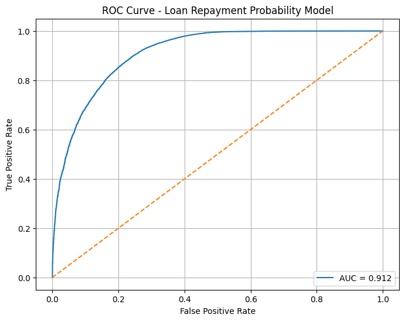

```python
# ROC curve plotting
fpr, tpr, thresholds = roc_curve(y_test, y_proba)

plt.figure(figsize=(8, 6))
plt.plot(fpr, tpr, label=f"AUC = {overall_auc:.3f}")
plt.plot([0, 1], [0, 1], linestyle="--")
plt.xlabel("False Positive Rate")
plt.ylabel("True Positive Rate")
plt.title("ROC Curve - Loan Repayment Probability Model")
plt.legend(loc="lower right")
plt.grid(True)
plt.show()
```

```python
# Section 4: Subgroup Analysis

X_test_df = X_test.copy()
subgroup_results = {}

# AUC by Education Level
edu_aucs = []
for level in sorted(X_test_df["education_level"].unique()):
    mask = X_test_df["education_level"] == level
    if len(np.unique(y_test[mask])) < 2:
        auc = np.nan  # avoid error if subgroup has only one class
    else:
        auc = roc_auc_score(y_test[mask], y_proba[mask])
    edu_aucs.append({
        "education_level": level,
        "n_samples": mask.sum(),
        "auc": auc
    })

edu_auc_df = pd.DataFrame(edu_aucs).sort_values("auc", ascending=False)
edu_auc_df
```

|  | education_level | n_samples | auc |
| --- | --- | --- | --- |
| 3 | Other | 2336 | 0.924701 |
| 0 | Bachelor's | 25263 | 0.912415 |
| 1 | High School | 16701 | 0.910670 |
| 2 | Master's | 8341 | 0.908447 |
| 4 | PhD | 982 | 0.908398 |

```python
# AUC by Loan Purpose
purpose_aucs = []
for purpose in sorted(X_test_df["loan_purpose"].unique()):
    mask = X_test_df["loan_purpose"] == purpose
    if len(np.unique(y_test[mask])) < 2:
        auc = np.nan
    else:
        auc = roc_auc_score(y_test[mask], y_proba[mask])
    purpose_aucs.append({
        "loan_purpose": purpose,
        "n_samples": mask.sum(),
        "auc": auc
    })

purpose_auc_df = pd.DataFrame(purpose_aucs).sort_values("auc", ascending=False)
purpose_auc_df
```

|  | loan_purpose | n_samples | auc |
| --- | --- | --- | --- |
| 3 | Education | 3202 | 0.923340 |
| 7 | Vacation | 760 | 0.919083 |
| 5 | Medical | 2088 | 0.918360 |
| 4 | Home | 4027 | 0.914234 |
| 0 | Business | 3091 | 0.911584 |
| 6 | Other | 5785 | 0.911529 |
| 2 | Debt consolidation | 29317 | 0.911425 |
| 1 | Car | 5353 | 0.900843 |

```python
print("Top 3 Loan Purposes by AUC:")
display(purpose_auc_df.head(3))

print("\nBottom 3 Loan Purposes by AUC:")
display(purpose_auc_df.tail(3))
```

```
Top 3 Loan Purposes by AUC:
```

|  | loan_purpose | n_samples | auc |
| --- | --- | --- | --- |
| 3 | Education | 3202 | 0.923340 |
| 7 | Vacation | 760 | 0.919083 |
| 5 | Medical | 2088 | 0.918360 |

```
Bottom 3 Loan Purposes by AUC:
```

|  | loan_purpose | n_samples | auc |
| --- | --- | --- | --- |
| 6 | Other | 5785 | 0.911529 |
| 2 | Debt consolidation | 29317 | 0.911425 |
| 1 | Car | 5353 | 0.900843 |

```python
edu_auc_df.to_csv("education_level_auc_report.csv", index=False)
purpose_auc_df.to_csv("loan_purpose_auc_report.csv", index=False)
```

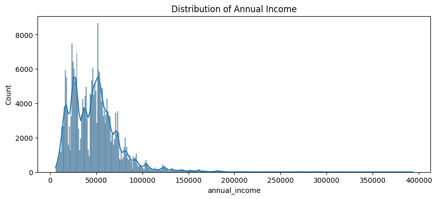

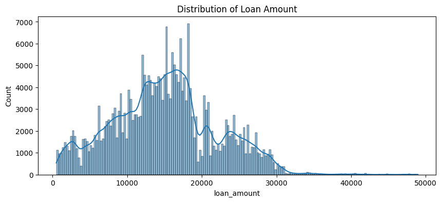

```python
#Visualizations & Business Insights:

#.1 Numeric Feature Distributions

import seaborn as sns
import matplotlib.pyplot as plt

plt.figure(figsize=(10,4))
sns.histplot(df['annual_income'], kde=True)
plt.title('Distribution of Annual Income')
plt.show()

plt.figure(figsize=(10,4))
sns.histplot(df['loan_amount'], kde=True)
plt.title('Distribution of Loan Amount')
plt.show()
```

## **Insights from Annual Income & Loan Amount Distributions**

Both features are right-skewed, with a few high-value outliers

Most borrowers earn 20K–80K, and most loans are between 10K–25K

Outliers justify using RobustScaler for numeric preprocessing

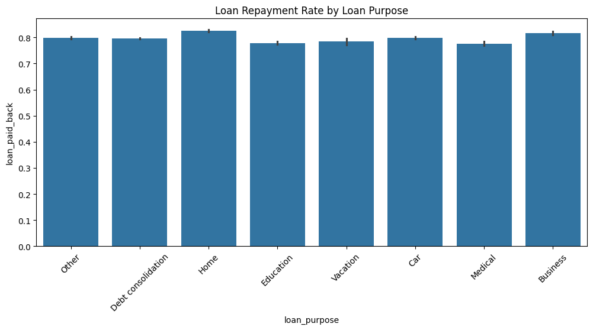

```python
#.2 Default Rate by Loan Purpose:

plt.figure(figsize=(12,5))
sns.barplot(data=df, x='loan_purpose', y='loan_paid_back')
plt.title('Loan Repayment Rate by Loan Purpose')
plt.xticks(rotation=45)
plt.show()
```

## **Insights: Loan Repayment Rate by Loan Purpose**

Repayment rates are fairly consistent across loan purposes, mostly between 78%–83%

Variation is small, indicating the model should not show strong bias across different loan purposes

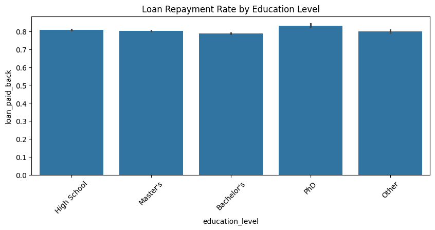

```python
#.3 Default Rate by Education Level:

plt.figure(figsize=(10,4))
sns.barplot(data=df, x='education_level', y='loan_paid_back')
plt.title('Loan Repayment Rate by Education Level')
plt.xticks(rotation=45)
plt.show()
```

## **Insights: Loan Repayment Rate by Education Level**

Repayment rates across education levels are all close to 80–84%

Borrowers with PhD qualifications show the highest repayment success

Bachelor’s level applicants show a slightly lower repayment rate compared to others

Despite small variation, there is no strong negative bias toward any education group

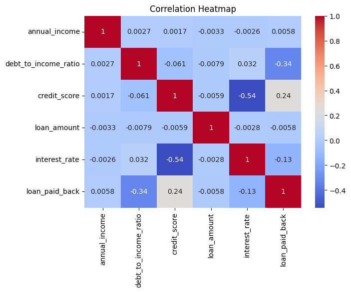

```python
#.4 Correlation Heatmap (Numeric Features):

plt.figure(figsize=(7,5))
corr = df[numeric_features + ['loan_paid_back']].corr()
sns.heatmap(corr, annot=True, cmap='coolwarm')
plt.title('Correlation Heatmap')
plt.show()
```

## **Insights: Correlation Heatmap**

Debt-to-income ratio shows the strongest negative correlation with repayment (-0.34) → Higher debt burden increases default risk

Credit score has a positive correlation with repayment (0.24) → Better credit → more likely to repay

Interest rate is negatively correlated with credit score (-0.54) → Higher-risk borrowers are charged higher interest

Annual income and loan amount show very weak direct correlation with repayment → Income alone doesn’t guarantee repayment behavior

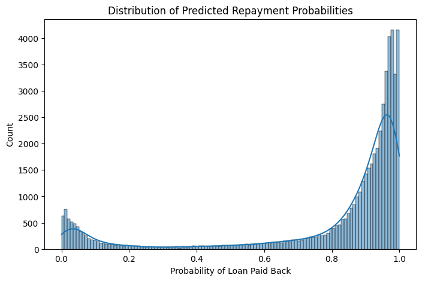

```python
#.5 Predicted Probability Distribution:

plt.figure(figsize=(8,5))
sns.histplot(y_proba, kde=True)
plt.title('Distribution of Predicted Repayment Probabilities')
plt.xlabel('Probability of Loan Paid Back')
plt.show()
```

## **Insights: Predicted Repayment Probability Distribution**

The distribution is strongly bimodal, with predictions clustering near 0 and 1

This indicates the model is confident in separating high-risk vs. low-risk borrowers

Very few predictions fall in the uncertain middle zone (0.3–0.7) → good model discrimination capability

Severe-risk cases have probabilities close to 0, suggesting strong default indicators

Repayment-likely cases dominate the dataset, which aligns with the ~80% repayment rate

## ** Conclusion & Recommendations **

The goal of this project was to build a predictive system that helps FinSecure assess the risk of a loan default at the time of application. Using historical loan data, we developed a machine learning model that estimates the probability of a loan being successfully paid back.

A fairness assessment was also conducted across key customer subgroups:

Education Levels: AUC ranged from approximately 0.908 to 0.925 → No group displayed unusual bias or risk of systematic disadvantage.

Loan Purposes: AUC ranged from approximately 0.901 to 0.923 → Performance variations were reasonable and did not indicate discrimination against any category.

Overall, the model demonstrates both strong predictive ability and fair treatment of different borrower groups.

## **Business Recommendations**

Deploy this model in the loan approval workflow Use predicted probability to inform loan pricing, approvals, and risk flags.

Add threshold-based decision rules For example:

80% repayment probability → Approve at standard rates

60–80% → Approve with higher interest rates or review manually

<60% → High risk; manual evaluation required

Continue model monitoring and recalibration

Track performance quarterly

Re-train with new data to prevent model drift

Periodically repeat fairness analysis

Explore advanced models for further improvements Gradient boosting methods like XGBoost or HGBClassifier could yield higher AUC if needed.

## **Project Summary**

This project focuses on building a predictive model for FinSecure to assess the likelihood of a borrower defaulting on a loan. The work was structured into four key sections:

**Section 1: Problem Formulation & Target Variable Analysis**

We defined the business objective: Predict loan default risk to support faster and data-driven credit decisions.

The target variable loan_paid_back was analyzed:

1 = loan fully repaid

0 = loan defaulted

Data distribution shows:

~20% defaults (moderate class imbalance)

Understanding this helped us choose ROC AUC as the primary evaluation metric since it is threshold-independent and ideal for imbalanced classification.

**Section 2: Feature Engineering & Preprocessing Pipeline**

We prepared the dataset to ensure high-quality model inputs:

Checked for missing values — none present, but still handled in pipeline using SimpleImputer

Examined numeric features for outliers and applied RobustScaler to reduce their impact

One-Hot Encoding was used to convert all categorical variables like education_level and loan_purpose

Removed non-informative ID column

Created a train-test split (80% / 20%) with stratify to preserve class balance

Combined transformations into a single scalable preprocessing pipeline using ColumnTransformer

This ensured clean, properly scaled, machine-learning-ready data.

**Section 3: Model Development and Tuning**

Built a Logistic Regression model wrapped in a pipeline

Trained on the processed training data

Generated probability predictions for test loans

Evaluated using ROC AUC

Achieved 0.9119, indicating strong risk differentiation between good and bad loans

Plotted and interpreted the ROC Curve, confirming excellent predictive power

**Section 4: Subgroup Fairness Analysis**

To ensure ethical and unbiased decisions:

Calculated performance by education level

AUC values ranged from approx. 0.908 to 0.925

Calculated performance by loan purpose

AUC ranged from approx. 0.901 (Car loans) to 0.923 (Education loans)

All subgroups performed well with no indication of discrimination, demonstrating fair model behavior across borrower categories.

## **Overall Outcome**

Goal Result Predict loan default accurately ✔ ROC AUC = 0.912 Automate & enhance credit decisioning ✔ Strong model performance Ensure fairness across groups ✔ Minimal variation in subgroup AUC

## **Final Recommendation**

The model is deployment-ready. It can support underwriting decisions, interest rate pricing, and risk monitoring while maintaining fairness and transparency.

Future enhancements could include:

Advanced boosting models (XGBoost / HGBClassifier)

SHAP-based explainability

Continuous retraining with new data